# 重賞レース予測レポート【レース終了】

作成日時: 2025/08/24 16:42:00

☞ [マニュアル(pdf)](https://ryutoro-galois.github.io/keiba-predictor/manual/manual.pdf)

☞ 過去5年の同一レース結果: [2024年](https://ryutoro-galois.github.io/keiba-predictor/report/PredResult_2024y_raceDate_20240824_20240825.html), [2023年](https://ryutoro-galois.github.io/keiba-predictor/report/PredResult_2023y_raceDate_20230826_20230827.html), [2022年](https://ryutoro-galois.github.io/keiba-predictor/report/PredResult_2022y_raceDate_20220827_20220828.html), [2021年](https://ryutoro-galois.github.io/keiba-predictor/report/PredResult_2021y_raceDate_20210828_20210829.html), [2020年](https://ryutoro-galois.github.io/keiba-predictor/report/PredResult_2020y_raceDate_20200829_20200830.html)

☞ 過去4週間の別レース結果: [1週前(8/16-17)](https://ryutoro-galois.github.io/keiba-predictor/report/PredResult_2025y_raceDate_20250816_20250817.html), [2週前(8/9-10)](https://ryutoro-galois.github.io/keiba-predictor/report/PredResult_2025y_raceDate_20250809_20250810.html), [3週前(8/3)](https://ryutoro-galois.github.io/keiba-predictor/report/PredResult_2025y_raceDate_20250803_20250803.html), [4週前(7/27)](https://ryutoro-galois.github.io/keiba-predictor/report/PredResult_2025y_raceDate_20250727_20250727.html)

☞ netkeiba: [新潟2歳ステークス(GⅢ)](https://race.netkeiba.com/race/result.html?race_id=202504030211&rf=race_submenu), [キーンランドカップ(GⅢ)](https://race.netkeiba.com/race/result.html?race_id=202501020211&rf=race_submenu)

☞ レース結果(csv): [8/23-24](https://ryutoro-galois.github.io/keiba-predictor/csv/race_result_20250823_20250824.csv)

## 【レース結果(1)】人気と着順の関係

### 【新潟2歳ステークス(2025/08/24(日))】

【新潟2歳ステークス(GⅢ)】  
2025/08/24(日), 04_新潟, 芝左外1600m

[interactive chart not shown]

### 【キーンランドカップ(2025/08/24(日))】

【キーンランドカップ(GⅢ)】  
2025/08/24(日), 01_札幌, 芝右1200m

[interactive chart not shown]

## 【レース結果(2)】コーナー通過順位

### 【新潟2歳ステークス(2025/08/24(日))】

【新潟2歳ステークス(GⅢ)】  
2025/08/24(日), 04_新潟, 芝左外1600m

[interactive chart not shown]

### 【キーンランドカップ(2025/08/24(日))】

【キーンランドカップ(GⅢ)】  
2025/08/24(日), 01_札幌, 芝右1200m

[interactive chart not shown]

## 0. 推し馬予測 (AI予測)

### 【新潟2歳ステークス(GⅢ) 2025/08/24(日)】

- 本命(◎): 1-3着内確率(勝負強さ)が1位の馬
- 対抗(◯): 1-3着内確率が2-N位(20%程度以上)の中で予測タイムが最も速い馬
- 3番手(▲): 1-3着内確率が2-N位(20%程度以上)のでダークホース確率が最も高い馬
- 穴: ダークホース確率が上位1-M位(40%程度以上)の中で1-3着内確率が最も高い馬

| 推し馬 | 枠番 | 馬番 | 人気 | オッズ | 馬名 | 騎手 | 調教師 | 予測タイム(sec) | 1_順位 | 1-3着内確率(%) | 2_順位 | ﾀﾞｰｸﾎｰｽ確率(%) | 3_順位 |
| --- | --- | --- | --- | --- | --- | --- | --- | --- | --- | --- | --- | --- | --- |
| 本命(◎) | 7 | 7 | 2 | 4.3 | サノノグレーター | 横山琉人 | 尾形和幸 | 101.1 | 8.0 | 35.4 | 1 | 0.4 | 10 |
| 対抗(◯) | 4 | 4 | 3 | 4.4 | フェスティバルヒル | 石橋脩 | 四位洋文 | 101.0 | 2.0 | 34.2 | 2 | 0.4 | 8 |
| 3番手(▲) | 3 | 3 | 6 | 12.7 | タイセイボーグ | 田口貫太 | 松下武士 | 101.0 | 3.5 | 15.2 | 6 | 37.8 | 3 |
| 穴 | 2 | 2 | 9 | 94.3 | リネンタイリン | 柴田大知 | 南田美知雄 | 101.2 | 9.5 | 10.0 | 7 | 43.1 | 1 |

### 【キーンランドカップ(GⅢ) 2025/08/24(日)】

- 本命(◎): 1-3着内確率(勝負強さ)が1位の馬
- 対抗(◯): 1-3着内確率が2-N位(20%程度以上)の中で予測タイムが最も速い馬
- 3番手(▲): 1-3着内確率が2-N位(20%程度以上)のでダークホース確率が最も高い馬
- 穴: ダークホース確率が上位1-M位(40%程度以上)の中で1-3着内確率が最も高い馬

| 推し馬 | 枠番 | 馬番 | 人気 | オッズ | 馬名 | 騎手 | 調教師 | 予測タイム(sec) | 1_順位 | 1-3着内確率(%) | 2_順位 | ﾀﾞｰｸﾎｰｽ確率(%) | 3_順位 |
| --- | --- | --- | --- | --- | --- | --- | --- | --- | --- | --- | --- | --- | --- |
| 本命(◎) | 8 | 16 | 3 | 5.7 | カルプスペルシュ | 横山武史 | 石坂公一 | 72.3 | 7 | 59.7 | 1 | 0.5 | 14 |
| 対抗(◯) | 3 | 5 | 2 | 5.5 | パンジャタワー | 松山弘平 | 橋口慎介 | 71.2 | 2 | 53.4 | 2 | 0.4 | 16 |
| 3番手(▲) | 8 | 15 | 8 | 12.3 | ナムラクララ | 浜中俊 | 長谷川浩大 | 72.2 | 5 | 24.2 | 6 | 1.6 | 9 |
| 穴 | 1 | 1 | 16 | 176.3 | ツインクルトーズ | 古川吉洋 | 牧光二 | 72.8 | 9 | 9.0 | 13 | 42.0 | 1 |

## 1. 予測チャート (タイム/勝負強さ)

### 【新潟2歳ステークス(GⅢ)】

2025/08/24(日), 04_新潟, 芝左外1600m

[interactive chart not shown]

### 【キーンランドカップ(GⅢ)】

2025/08/24(日), 01_札幌, 芝右1200m

[interactive chart not shown]

## 2. オッズモニタリング (毎時)

### 【新潟2歳ステークス】

[interactive chart not shown]

### 【キーンランドカップ】

[interactive chart not shown]

## 3. 出馬表

### 【新潟2歳ステークス 2025/08/24(日) 】

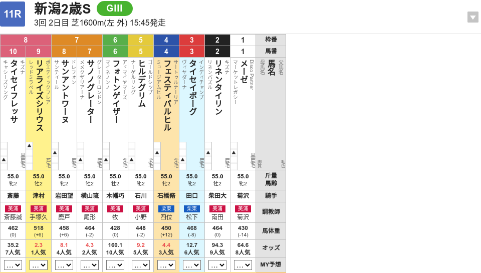

### 【キーンランドカップ 2025/08/24(日) 】

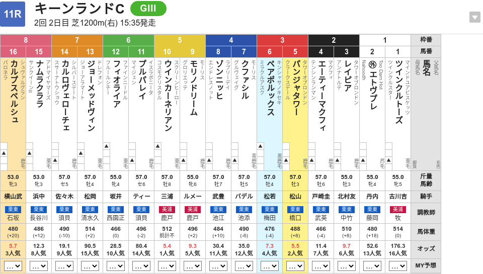

## 4. 単勝予測結果

### 【新潟2歳ステークス(GⅢ) 2025/08/24(日)】

| 枠番 | 馬番 | 人気 | オッズ | 馬名 | 騎手 | 調教師 | 予測タイム(sec) | 1_順位 | 1-3着内確率(%) | 2_順位 | ﾀﾞｰｸﾎｰｽ確率(%) | 3_順位 |
| --- | --- | --- | --- | --- | --- | --- | --- | --- | --- | --- | --- | --- |
| 1 | 1 | 8 | 64.6 | メーゼ | 菊沢一樹 | 菊沢隆徳 | 101.0 | 5.5 | 9.0 | 8 | 40.0 | 2 |
| 2 | 2 | 9 | 94.3 | リネンタイリン | 柴田大知 | 南田美知雄 | 101.2 | 9.5 | 10.0 | 7 | 43.1 | 1 |
| 3 | 3 | 6 | 12.7 | タイセイボーグ | 田口貫太 | 松下武士 | 101.0 | 3.5 | 15.2 | 6 | 37.8 | 3 |
| 4 | 4 | 3 | 4.4 | フェスティバルヒル | 石橋脩 | 四位洋文 | 101.0 | 2.0 | 34.2 | 2 | 0.4 | 8 |
| 5 | 5 | 5 | 9.2 | ヒルデグリム | 石川裕紀人 | 小野次郎 | 101.0 | 3.5 | 16.7 | 5 | 1.5 | 6 |
| 6 | 6 | 10 | 160.1 | フォトンゲイザー | 木幡巧也 | 牧光二 | 101.2 | 9.5 | 7.0 | 10 | 36.6 | 4 |
| 7 | 7 | 2 | 4.3 | サノノグレーター | 横山琉人 | 尾形和幸 | 101.1 | 8.0 | 35.4 | 1 | 0.4 | 10 |
| 7 | 8 | 4 | 8.1 | サンアントワーヌ | 岩田望来 | 鹿戸雄一 | 101.0 | 7.0 | 19.4 | 3 | 1.5 | 7 |
| 8 | 9 | 1 | 2.3 | リアライズシリウス | 津村明秀 | 手塚貴久 | 93.4 | 1.0 | 16.8 | 4 | 0.4 | 9 |
| 8 | 10 | 7 | 35.2 | タイセイフレッサ | 斎藤新 | 斎藤誠 | 101.0 | 5.5 | 8.8 | 9 | 33.1 | 5 |

### 【キーンランドカップ(GⅢ) 2025/08/24(日)】

| 枠番 | 馬番 | 人気 | オッズ | 馬名 | 騎手 | 調教師 | 予測タイム(sec) | 1_順位 | 1-3着内確率(%) | 2_順位 | ﾀﾞｰｸﾎｰｽ確率(%) | 3_順位 |
| --- | --- | --- | --- | --- | --- | --- | --- | --- | --- | --- | --- | --- |
| 1 | 1 | 16 | 176.3 | ツインクルトーズ | 古川吉洋 | 牧光二 | 72.8 | 9 | 9.0 | 13 | 42.0 | 1 |
| 1 | 2 | 13 | 52.6 | エトヴプレ | 丹内祐次 | 藤岡健一 | 75.0 | 13 | 9.4 | 11 | 38.2 | 3 |
| 2 | 3 | 6 | 9.7 | レイピア | 北村友一 | 中竹和也 | 72.0 | 4 | 27.3 | 4 | 1.2 | 11 |
| 2 | 4 | 7 | 11.4 | エーティーマクフィ | 戸崎圭太 | 武英智 | 75.4 | 16 | 24.4 | 5 | 1.5 | 10 |
| 3 | 5 | 2 | 5.5 | パンジャタワー | 松山弘平 | 橋口慎介 | 71.2 | 2 | 53.4 | 2 | 0.4 | 16 |
| 3 | 6 | 4 | 7.3 | ペアポルックス | 松若風馬 | 梅田智之 | 74.5 | 12 | 43.1 | 3 | 0.5 | 15 |
| 4 | 7 | 12 | 35.0 | クファシル | Ａ．バデル | 池添学 | 72.3 | 6 | 9.8 | 10 | 38.8 | 2 |
| 4 | 8 | 11 | 30.4 | ゾンニッヒ | 武豊 | 池江泰寿 | 74.5 | 11 | 3.8 | 16 | 15.2 | 7 |
| 5 | 9 | 5 | 9.3 | モリノドリーム | Ｃ．ルメール | 鹿戸雄一 | 74.3 | 10 | 9.1 | 12 | 0.9 | 12 |
| 5 | 10 | 1 | 5.4 | ウインカーネリアン | 三浦皇成 | 鹿戸雄一 | 67.6 | 1 | 14.4 | 8 | 0.6 | 13 |

[output cut: 6 more lines]

## 5. 人気と着順の乖離率推移

### 【新潟2歳ステークス_2001y_2019y】

[interactive chart not shown]

### 【キーンランドカップ_2006y_2019y】

[interactive chart not shown]

### 【新潟2歳ステークス_2001y_2019y】

| No | 開催年 | 不整合率(%) | 頭数 | 人気別着順(1-3位) | 人気別着順(全体) |
| --- | --- | --- | --- | --- | --- |
| 19 | 2019 | 32.9 | 16頭 | 1-3-8 | 1\|3\|8\|7\|5\|12\|6\|2\|13\|11\|9\|16\|4\|14\|15\|10 |
| 18 | 2018 | 5.2 | 11頭 | 1-2-8 | 1\|2\|8\|3\|4\|5\|9\|10\|6\|7\|11 |
| 17 | 2017 | 58.7 | 15頭 | 3-5-2 | 3\|5\|2\|11\|14\|6\|4\|10\|7\|15\|12\|1\|9\|13\|8 |
| 16 | 2016 | 55.8 | 15頭 | 3-6-2 | 3\|6\|2\|8\|4\|12\|5\|1\|14\|10\|9\|7\|13\|11\|15 |
| 15 | 2015 | 24.3 | 18頭 | 1-12-8 | 1\|12\|8\|5\|10\|2\|17\|3\|6\|16\|9\|11\|7\|13\|15\|18\|4\|14 |
| 14 | 2014 | 37.1 | 18頭 | 3-1-6 | 3\|1\|6\|12\|5\|2\|10\|4\|14\|7\|16\|13\|8\|11\|9\|17\|15\|18 |
| 13 | 2013 | 37.5 | 18頭 | 1-4-6 | 1\|4\|6\|14\|5\|10\|3\|7\|2\|9\|15\|13\|11\|18\|16\|8\|12\|17 |
| 12 | 2012 | 41.0 | 18頭 | 3-10-9 | 3\|10\|9\|1\|2\|12\|14\|15\|6\|8\|18\|5\|4\|13\|17\|16\|7\|11 |
| 11 | 2011 | 33.5 | 18頭 | 4-1-9 | 4\|1\|9\|2\|8\|13\|17\|6\|12\|5\|14\|16\|10\|18\|7\|3\|15\|11 |
| 10 | 2010 | 56.6 | 17頭 | 9-10-5 | 9\|10\|5\|4\|11\|6\|8\|2\|14\|1\|12\|3\|17\|7\|13\|16\|15 |

[output cut: 9 more lines]

### 【キーンランドカップ_2006y_2019y】

| No | 開催年 | 不整合率(%) | 頭数 | 人気別着順(1-3位) | 人気別着順(全体) |
| --- | --- | --- | --- | --- | --- |
| 14 | 2019 | 5.8 | 16頭 | 1-2-3 | 1\|2\|3\|11\|4\|5\|13\|6\|15\|8\|9\|10\|14\|12\|16\|7 |
| 13 | 2018 | 24.9 | 16頭 | 1-4-9 | 1\|4\|9\|5\|14\|2\|6\|7\|3\|16\|13\|10\|12\|8\|11\|15 |
| 12 | 2017 | 38.1 | 13頭 | 12-2-5 | 12\|2\|5\|11\|13\|1\|4\|10\|6\|9\|7\|8\|3 |
| 11 | 2016 | 18.4 | 14頭 | 2-1-3 | 2\|1\|3\|4\|9\|6\|8\|5\|13\|10\|14\|7\|11\|12 |
| 10 | 2015 | 28.3 | 16頭 | 8-9-1 | 8\|9\|1\|4\|2\|6\|5\|11\|3\|10\|12\|7\|15\|16\|13\|14 |
| 9 | 2014 | 37.5 | 16頭 | 3-1-5 | 3\|1\|5\|9\|7\|8\|2\|4\|10\|6\|12\|11\|15\|16\|13\|14 |
| 8 | 2013 | 34.6 | 15頭 | 4-1-6 | 4\|1\|6\|2\|10\|14\|7\|13\|16\|9\|8\|12\|5\|3\|15 |
| 7 | 2012 | 36.6 | 14頭 | 3-1-4 | 3\|1\|4\|5\|7\|10\|2\|6\|8\|11\|14\|13\|12\|9 |
| 6 | 2011 | 33.6 | 16頭 | 1-6-4 | 1\|6\|4\|7\|13\|12\|8\|5\|2\|10\|9\|16\|14\|3\|11\|15 |
| 5 | 2010 | 32.4 | 16頭 | 2-6-8 | 2\|6\|8\|1\|4\|7\|10\|3\|13\|5\|12\|11\|9\|15\|14\|16 |

[output cut: 4 more lines]

## 6. 1-3番人気馬の着順分類予測

### 【新潟2歳ステークス】

| 分類 | 凡例 | 発生確率(%) | 当該レース | 当該レースランク | 直近1年間 |
| --- | --- | --- | --- | --- | --- |
| 1: 1番人気のみ (1_pop1) | 1 \| * \| * | 17.6 | 0.70 | 0.76 | 0.00 |
| 4: 1,2番人気のみ (4_pop12) | 1 \| 2 \| * | 16.5 | 0.99 | 1.01 | 0.00 |
| 5: 1,3番人気のみ (5_pop13) | 1 \| 3 \| * | 15.5 | 0.47 | 0.67 | 0.31 |
| 8: 1,2,3番人気すべて着外 (8_darkhorse) | * \| * \| * | 14.2 | 1.71 | 2.03 | 0.00 |
| 6: 2,3番人気のみ (6_pop23) | 2 \| 3 \| * | 9.9 | 1.19 | 1.41 | 0.00 |
| 2: 2番人気のみ (2_pop2) | 2 \| * \| * | 9.8 | 0.00 | 4.26 | 0.00 |
| 3: 3番人気のみ (3_pop3) | 3 \| * \| * | 9.4 | 2.24 | 4.09 | 0.00 |
| 7: 1,2,3番人気すべて着内 (7_pop123) | 1 \| 2 \| 3 | 7.1 | 1.69 | 0.38 | 0.14 |

### 【キーンランドカップ】

| 分類 | 凡例 | 発生確率(%) | 当該レース | 当該レースランク | 直近1年間 |
| --- | --- | --- | --- | --- | --- |
| 1: 1番人気のみ (1_pop1) | 1 \| * \| * | 17.1 | 0.81 | 0.73 | 0.00 |
| 4: 1,2番人気のみ (4_pop12) | 1 \| 2 \| * | 16.3 | 1.03 | 1.00 | 0.00 |
| 8: 1,2,3番人気すべて着外 (8_darkhorse) | * \| * \| * | 13.9 | 2.62 | 1.99 | 0.00 |
| 5: 1,3番人気のみ (5_pop13) | 1 \| 3 \| * | 13.8 | 1.31 | 0.59 | 0.28 |
| 7: 1,2,3番人気すべて着内 (7_pop123) | 1 \| 2 \| 3 | 10.6 | 0.29 | 0.57 | 0.21 |
| 6: 2,3番人気のみ (6_pop23) | 2 \| 3 \| * | 9.6 | 1.81 | 1.37 | 0.00 |
| 2: 2番人気のみ (2_pop2) | 2 \| * \| * | 9.5 | 1.79 | 4.13 | 0.00 |
| 3: 3番人気のみ (3_pop3) | 3 \| * \| * | 9.2 | 0.00 | 4.00 | 0.00 |

## 7. 3連複予測結果

### 【新潟2歳ステークス(GⅢ) 2025/08/24(日)】

| 分類 | 馬番 | 枠番 | 人気 | 平均予測タイム(sec) | 1-3着内確率(%) | ﾀﾞｰｸﾎｰｽ確率(%) | 馬名 | 騎手 | 調教師 |
| --- | --- | --- | --- | --- | --- | --- | --- | --- | --- |
| 6: 2,3番人気のみ (6_pop23) | 7-4-8 | 7-4-7 | 2-3-4 | 101.03 | 2.34 | 0.00 | サノノグレーター \| フェスティバルヒル \| サンアントワーヌ | 横山琉人 \| 石橋脩 \| 岩田望来 | 尾形和幸 \| 四位洋文 \| 鹿戸雄一 |
| 7: 1,2,3番人気すべて着内 (7_pop123) | 9-7-4 | 8-7-4 | 1-2-3 | 98.50 | 2.03 | 0.00 | リアライズシリウス \| サノノグレーター \| フェスティバルヒル | 津村明秀 \| 横山琉人 \| 石橋脩 | 手塚貴久 \| 尾形和幸 \| 四位洋文 |
| 6: 2,3番人気のみ (6_pop23) | 7-4-5 | 7-4-5 | 2-3-5 | 101.03 | 2.02 | 0.00 | サノノグレーター \| フェスティバルヒル \| ヒルデグリム | 横山琉人 \| 石橋脩 \| 石川裕紀人 | 尾形和幸 \| 四位洋文 \| 小野次郎 |
| 6: 2,3番人気のみ (6_pop23) | 7-4-3 | 7-4-3 | 2-3-6 | 101.03 | 1.83 | 0.00 | サノノグレーター \| フェスティバルヒル \| タイセイボーグ | 横山琉人 \| 石橋脩 \| 田口貫太 | 尾形和幸 \| 四位洋文 \| 松下武士 |
| 6: 2,3番人気のみ (6_pop23) | 7-4-2 | 7-4-2 | 2-3-9 | 101.10 | 1.20 | 0.00 | サノノグレーター \| フェスティバルヒル \| リネンタイリン | 横山琉人 \| 石橋脩 \| 柴田大知 | 尾形和幸 \| 四位洋文 \| 南田美知雄 |
| 4: 1,2番人気のみ (4_pop12) | 9-7-8 | 8-7-7 | 1-2-4 | 98.50 | 1.15 | 0.00 | リアライズシリウス \| サノノグレーター \| サンアントワーヌ | 津村明秀 \| 横山琉人 \| 岩田望来 | 手塚貴久 \| 尾形和幸 \| 鹿戸雄一 |
| 2: 2番人気のみ (2_pop2) | 7-8-5 | 7-7-5 | 2-4-5 | 101.03 | 1.14 | 0.00 | サノノグレーター \| サンアントワーヌ \| ヒルデグリム | 横山琉人 \| 岩田望来 \| 石川裕紀人 | 尾形和幸 \| 鹿戸雄一 \| 小野次郎 |
| 5: 1,3番人気のみ (5_pop13) | 9-4-8 | 8-4-7 | 1-3-4 | 98.47 | 1.11 | 0.00 | リアライズシリウス \| フェスティバルヒル \| サンアントワーヌ | 津村明秀 \| 石橋脩 \| 岩田望来 | 手塚貴久 \| 四位洋文 \| 鹿戸雄一 |
| 3: 3番人気のみ (3_pop3) | 4-8-5 | 4-7-5 | 3-4-5 | 101.00 | 1.10 | 0.00 | フェスティバルヒル \| サンアントワーヌ \| ヒルデグリム | 石橋脩 \| 岩田望来 \| 石川裕紀人 | 四位洋文 \| 鹿戸雄一 \| 小野次郎 |
| 6: 2,3番人気のみ (6_pop23) | 7-4-1 | 7-4-1 | 2-3-8 | 101.03 | 1.09 | 0.00 | サノノグレーター \| フェスティバルヒル \| メーゼ | 横山琉人 \| 石橋脩 \| 菊沢一樹 | 尾形和幸 \| 四位洋文 \| 菊沢隆徳 |

[output cut: 110 more lines]

### 【キーンランドカップ(GⅢ) 2025/08/24(日)】

| 分類 | 馬番 | 枠番 | 人気 | 平均予測タイム(sec) | 1-3着内確率(%) | ﾀﾞｰｸﾎｰｽ確率(%) | 馬名 | 騎手 | 調教師 |
| --- | --- | --- | --- | --- | --- | --- | --- | --- | --- |
| 6: 2,3番人気のみ (6_pop23) | 5-16-6 | 3-8-3 | 2-3-4 | 72.67 | 13.76 | 0.00 | パンジャタワー \| カルプスペルシュ \| ペアポルックス | 松山弘平 \| 横山武史 \| 松若風馬 | 橋口慎介 \| 石坂公一 \| 梅田智之 |
| 6: 2,3番人気のみ (6_pop23) | 5-16-3 | 3-8-2 | 2-3-6 | 71.83 | 8.71 | 0.00 | パンジャタワー \| カルプスペルシュ \| レイピア | 松山弘平 \| 横山武史 \| 北村友一 | 橋口慎介 \| 石坂公一 \| 中竹和也 |
| 6: 2,3番人気のみ (6_pop23) | 5-16-4 | 3-8-2 | 2-3-7 | 72.97 | 7.78 | 0.00 | パンジャタワー \| カルプスペルシュ \| エーティーマクフィ | 松山弘平 \| 横山武史 \| 戸崎圭太 | 橋口慎介 \| 石坂公一 \| 武英智 |
| 6: 2,3番人気のみ (6_pop23) | 5-16-15 | 3-8-8 | 2-3-8 | 71.90 | 7.71 | 0.00 | パンジャタワー \| カルプスペルシュ \| ナムラクララ | 松山弘平 \| 横山武史 \| 浜中俊 | 橋口慎介 \| 石坂公一 \| 長谷川浩大 |
| 3: 3番人気のみ (3_pop3) | 16-6-3 | 8-3-2 | 3-4-6 | 72.93 | 7.03 | 0.00 | カルプスペルシュ \| ペアポルックス \| レイピア | 横山武史 \| 松若風馬 \| 北村友一 | 石坂公一 \| 梅田智之 \| 中竹和也 |
| 2: 2番人気のみ (2_pop2) | 5-6-3 | 3-3-2 | 2-4-6 | 72.57 | 6.29 | 0.00 | パンジャタワー \| ペアポルックス \| レイピア | 松山弘平 \| 松若風馬 \| 北村友一 | 橋口慎介 \| 梅田智之 \| 中竹和也 |
| 3: 3番人気のみ (3_pop3) | 16-6-4 | 8-3-2 | 3-4-7 | 74.07 | 6.28 | 0.00 | カルプスペルシュ \| ペアポルックス \| エーティーマクフィ | 横山武史 \| 松若風馬 \| 戸崎圭太 | 石坂公一 \| 梅田智之 \| 武英智 |
| 3: 3番人気のみ (3_pop3) | 16-6-15 | 8-3-8 | 3-4-8 | 73.00 | 6.22 | 0.00 | カルプスペルシュ \| ペアポルックス \| ナムラクララ | 横山武史 \| 松若風馬 \| 浜中俊 | 石坂公一 \| 梅田智之 \| 長谷川浩大 |
| 6: 2,3番人気のみ (6_pop23) | 5-16-14 | 3-8-7 | 2-3-9 | 72.90 | 5.91 | 0.00 | パンジャタワー \| カルプスペルシュ \| カルロヴェローチェ | 松山弘平 \| 横山武史 \| 佐々木大輔 | 橋口慎介 \| 石坂公一 \| 須貝尚介 |
| 2: 2番人気のみ (2_pop2) | 5-6-4 | 3-3-2 | 2-4-7 | 73.70 | 5.62 | 0.00 | パンジャタワー \| ペアポルックス \| エーティーマクフィ | 松山弘平 \| 松若風馬 \| 戸崎圭太 | 橋口慎介 \| 梅田智之 \| 武英智 |

[output cut: 550 more lines]

## 8. 直近の全レース情報

| No | 日付 | 競馬場 | R | 発走 | レース名 | 距離 | 頭数 | URL(netkeiba) |
| --- | --- | --- | --- | --- | --- | --- | --- | --- |
| 1 | 2025/08/23(土) | 04_新潟 | 9R | 14:35 | 岩室温泉特別 | 1200 | 24頭 | https://race.netkeiba.com/race/shutuba.html?race_id=202504030109&amp;rf=race_list |
| 2 | 2025/08/23(土) | 04_新潟 | 10R | 15:10 | 飯豊特別 | 1400 | 21頭 | https://race.netkeiba.com/race/shutuba.html?race_id=202504030110&amp;rf=race_list |
| 3 | 2025/08/23(土) | 04_新潟 | 11R | 15:45 | BSN賞 | 1800 | 12頭 | https://race.netkeiba.com/race/shutuba.html?race_id=202504030111&amp;rf=race_list |
| 4 | 2025/08/23(土) | 07_中京 | 9R | 14:15 | 長良川特別 | 2200 | 13頭 | https://race.netkeiba.com/race/shutuba.html?race_id=202507040109&amp;rf=race_list |
| 5 | 2025/08/23(土) | 07_中京 | 10R | 14:50 | 有松特別 | 1600 | 16頭 | https://race.netkeiba.com/race/shutuba.html?race_id=202507040110&amp;rf=race_list |
| 6 | 2025/08/23(土) | 07_中京 | 11R | 15:25 | 伊賀S | 1400 | 19頭 | https://race.netkeiba.com/race/shutuba.html?race_id=202507040111&amp;rf=race_list |
| 7 | 2025/08/23(土) | 01_札幌 | 9R | 14:25 | クローバー賞 | 1500 | 11頭 | https://race.netkeiba.com/race/shutuba.html?race_id=202501020109&amp;rf=race_list |
| 8 | 2025/08/23(土) | 01_札幌 | 10R | 15:00 | WASJ1 | 1200 | 18頭 | https://race.netkeiba.com/race/shutuba.html?race_id=202501020110&amp;rf=race_list |
| 9 | 2025/08/23(土) | 01_札幌 | 11R | 15:35 | WASJ2 | 2000 | 24頭 | https://race.netkeiba.com/race/shutuba.html?race_id=202501020111&amp;rf=race_list |
| 10 | 2025/08/23(土) | 01_札幌 | 12R | 16:15 | ニセコ特別 | 1700 | 18頭 | https://race.netkeiba.com/race/shutuba.html?race_id=202501020112&amp;rf=race_list |

[output cut: 10 more lines]